# Template of Final Project

Dr. Islam

2024-11-17

### Introduction

Chronic Kidney Disease (CKD) is a progressive condition characterized by a gradual loss of kidney function over time. Early detection and intervention are crucial to preventing the progression of CKD and improving patient outcomes. Understanding the relationships between various risk factors and CKD can help healthcare professionals identify high-risk individuals and develop effective prevention strategies. The Chronic Kidney Disease dataset provides detailed information on patient demographics, medical history, and various physiological measurements. This project aims to explore the relationships between factors such as age, blood pressure, blood glucose levels, and the presence of comorbidities (e.g., diabetes mellitus, hypertension) in relation to CKD classification.

### Research Questions

The study will address the following research questions using different inferential statistical methods:

1. Is there a significant difference in the mean blood pressure (bp) between patients with chronic kidney disease (class = 1) and those without (class = 0)?
2. Is the proportion of CKD patients with diabetes mellitus (dm = 1) different from the proportion of patients without diabetes mellitus (dm = 0) in the overall sample?
3. Is there an association between the presence of pedal edema (pe) and anemia (ane) in patients with CKD?
4. How do factors such as age, blood glucose (bgr), serum creatinine (sc), blood pressure (bp), and diabetes mellitus (dm) affect the level of blood urea (bu) in CKD patients, controlling for other factors like hypertension (htn) and coronary artery disease (cad)?

### Methodology

#### Data Description

Dataset called “chronic kidney disease” was collected from the website Kaggle. The dataset consists of several variables, including:

- Demographic variables: age
- Physiological measurements: blood pressure (bp), specific gravity (sg), albumin (al), blood glucose (bgr), serum creatinine (sc), sodium (sod), potassium (pot), hemoglobin (hemo), packed cell volume (pcv), white blood cell count (wc), red blood cell count (rc).
- Clinical indicators: hypertension (htn), diabetes mellitus (dm), coronary artery disease (cad), appetite (appet), pedal edema (pe), anemia (ane).

#### Data Analysis

- The dataset is cleaned to remove missing or inconsistent values.
- Descriptive statistics, including means, medians, standard deviations, and frequency distributions, will be calculated for continuous and categorical variables.
- Visualizations such as boxplot and bar charts are used to illustrate distributions.
- The following inferential statistics will be performed using appropriate tests (t-test, z-test, chi-square test, and regression analysis).

```r
library(dplyr)
library(ggplot2)
CKD<-read.csv("kidney_disease.csv",na.strings = c("NA"," ", "" ))
str(CKD)
```

```
## 'data.frame':    400 obs. of  26 variables:
##  $ id            : int  0 1 2 3 4 5 6 7 8 9 ...
##  $ age           : num  48 7 62 48 51 60 68 24 52 53 ...
##  $ bp            : num  80 50 80 70 80 90 70 NA 100 90 ...
##  $ sg            : num  1.02 1.02 1.01 1 1.01 ...
##  $ al            : num  1 4 2 4 2 3 0 2 3 2 ...
##  $ su            : num  0 0 3 0 0 0 0 4 0 0 ...
##  $ rbc           : chr  NA NA "normal" "normal" ...
##  $ pc            : chr  "normal" "normal" "normal" "abnormal" ...
##  $ pcc           : chr  "notpresent" "notpresent" "notpresent" "present" ...
##  $ ba            : chr  "notpresent" "notpresent" "notpresent" "notpresent" ...
##  $ bgr           : num  121 NA 423 117 106 74 100 410 138 70 ...
##  $ bu            : num  36 18 53 56 26 25 54 31 60 107 ...
##  $ sc            : num  1.2 0.8 1.8 3.8 1.4 1.1 24 1.1 1.9 7.2 ...
##  $ sod           : num  NA NA NA 111 NA 142 104 NA NA 114 ...
##  $ pot           : num  NA NA NA 2.5 NA 3.2 4 NA NA 3.7 ...
##  $ hemo          : num  15.4 11.3 9.6 11.2 11.6 12.2 12.4 12.4 10.8 9.5 ...
##  $ pcv           : chr  "44" "38" "31" "32" ...
##  $ wc            : chr  "7800" "6000" "7500" "6700" ...
##  $ rc            : chr  "5.2" NA NA "3.9" ...
##  $ htn           : chr  "yes" "no" "no" "yes" ...
##  $ dm            : chr  "yes" "no" "yes" "no" ...
##  $ cad           : chr  "no" "no" "no" "no" ...
##  $ appet         : chr  "good" "good" "poor" "poor" ...
##  $ pe            : chr  "no" "no" "no" "yes" ...
##  $ ane           : chr  "no" "no" "yes" "yes" ...
##  $ classification: chr  "ckd" "ckd" "ckd" "ckd" ...
```

```r
a=complete.cases(CKD)
table(a) # dataset has missing data
```

```
## a
## FALSE  TRUE
##   242   158
```

```r
df<-CKD[a, ]

dim(df)
```

```
## [1] 158  26
```

```r
table(df$classification)
```

```
##
##    ckd notckd
##     43    115
```

##### 1. Is there a significant difference in the mean blood pressure (bp) between patients with chronic kidney disease (class = 1) and those without (class = 0)?

```r
f<-function(x){

  return(c(mean=mean(x), s=sd(x)))
}
tapply(df$bp, df$classification, FUN=f)
```

```
## $ckd
##     mean        s
## 80.00000 14.47494
##
## $notckd
##      mean         s
## 71.826087  8.744182
```

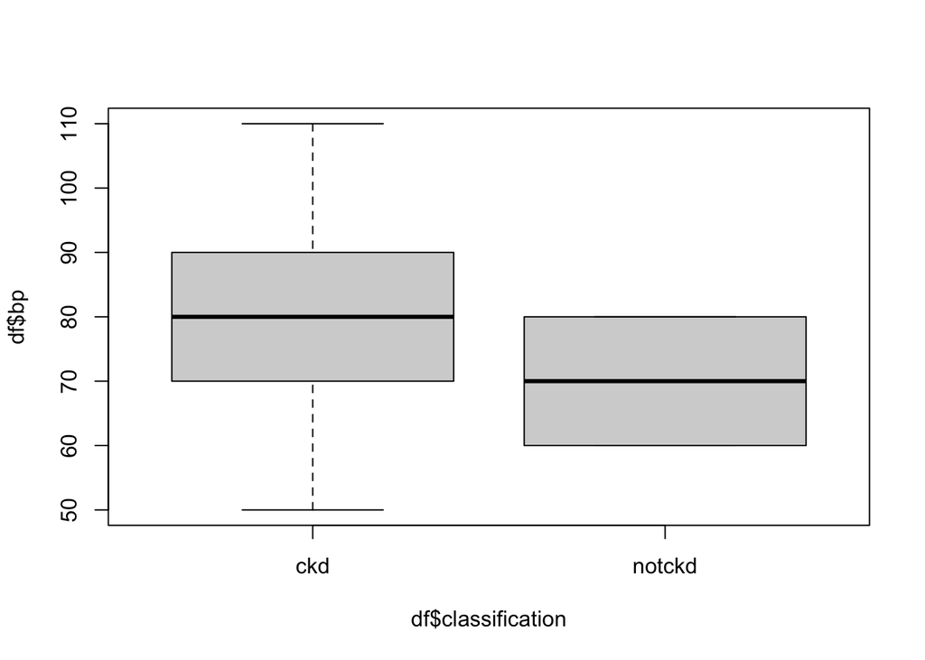

```r
boxplot(df$bp ~df$classification)
```

```r
t.test(df$bp ~df$classification, alternative="two.sided", conf.level=0.95)
```

```
##
##  Welch Two Sample t-test
##
## data:  df$bp by df$classification
## t = 3.4735, df = 53.874, p-value = 0.001021
## alternative hypothesis: true difference in means between group ckd and group notckd is not equal to 0
## 95 percent confidence interval:
##   3.455791 12.892035
## sample estimates:
##    mean in group ckd mean in group notckd
##             80.00000             71.82609
```

##### 2. Is the proportion of CKD patients with diabetes mellitus (dm = 1) different from the proportion of patients without diabetes mellitus (dm = 0) in the overall sample?

```r
Tab=table(df$dm, df$classification)
Tab
```

```
##
##       ckd notckd
##   no   15    115
##   yes  28      0
```

```r
prop.table(Tab,1)
```

```
##
##             ckd    notckd
##   no  0.1153846 0.8846154
##   yes 1.0000000 0.0000000
```

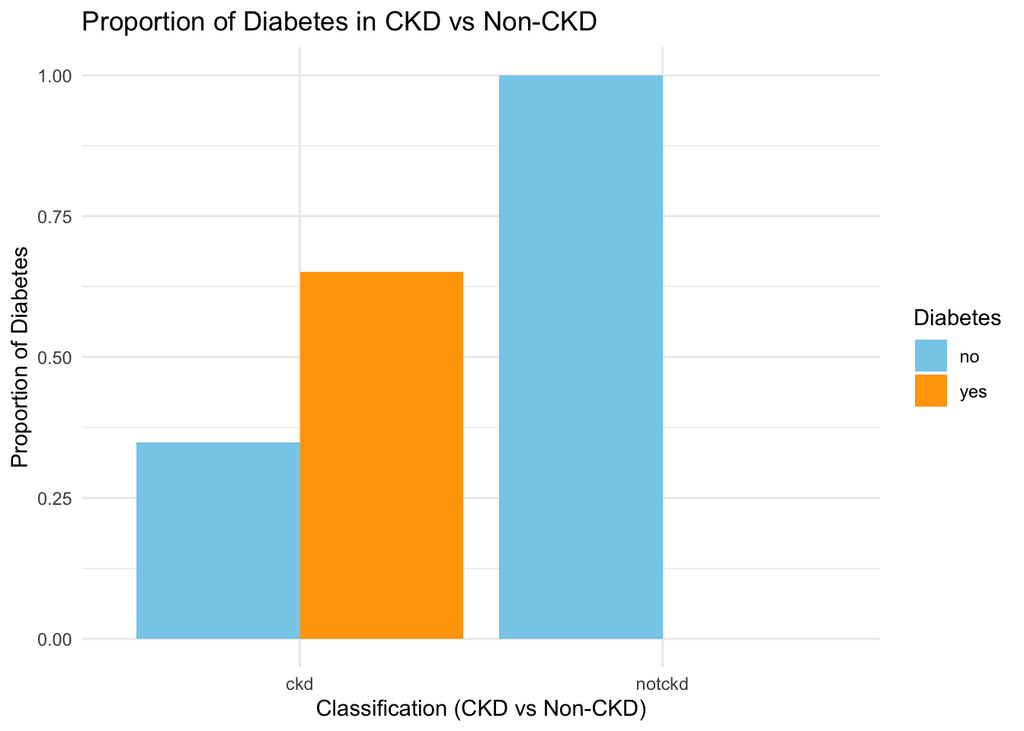

```r
df_tab <- as.data.frame(Tab)
colnames(df_tab) <- c("Diabetes", "Classification", "Count")

df_tab <- df_tab %>%
  group_by(Classification) %>%
  mutate(Proportion = Count / sum(Count))

ggplot(df_tab, aes(x = Classification, y = Proportion, fill = Diabetes)) +
  geom_bar(stat = "identity", position = "dodge") +
  labs(title = "Proportion of Diabetes in CKD vs Non-CKD",
       x = "Classification (CKD vs Non-CKD)",
       y = "Proportion of Diabetes") +
  scale_fill_manual(values = c("skyblue", "orange")) +
  theme_minimal()
```

```r
prop.test(x=c(15, 28), n=c(15+115, 28+0), correct = FALSE)
```

```
##
##  2-sample test for equality of proportions without continuity correction
##
## data:  c(15, 28) out of c(15 + 115, 28 + 0)
## X-squared = 91.013, df = 1, p-value < 2.2e-16
## alternative hypothesis: two.sided
## 95 percent confidence interval:
##  -0.9395350 -0.8296958
## sample estimates:
##    prop 1    prop 2
## 0.1153846 1.0000000
```

##### 3. Is there an association between the presence of pedal edema (pe) and anemia (ane) in patients with CKD?

```r
Tab1=table(df$pe, df$ane)
Tab1
```

```
##
##        no yes
##   no  130   8
##   yes  12   8
```

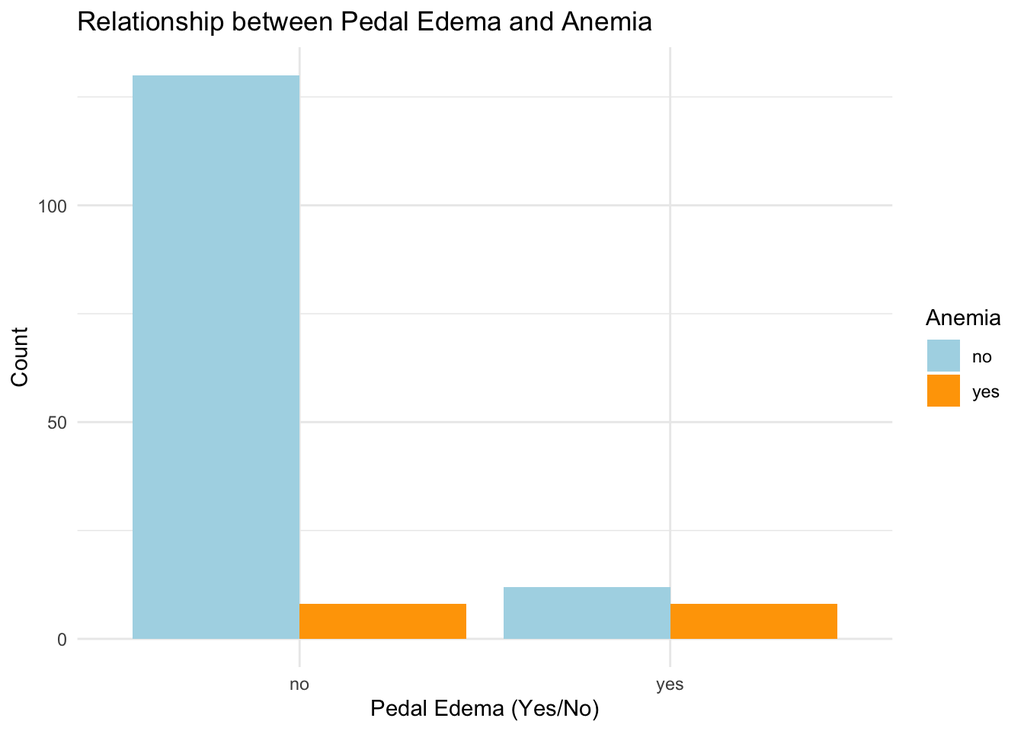

```r
df_tab1 <- as.data.frame(Tab1)
colnames(df_tab1) <- c("PedalEdema", "Anemia", "Count")

ggplot(df_tab1, aes(x = PedalEdema, y = Count, fill = Anemia)) +
  geom_bar(stat = "identity", position = "dodge") +
  labs(title = "Relationship between Pedal Edema and Anemia",
       x = "Pedal Edema (Yes/No)",
       y = "Count",
       fill = "Anemia") +
  theme_minimal() +
  scale_fill_manual(values = c("lightblue", "orange"))
```

```r
chisq.test(Tab1, correct=FALSE)
```

```
##
##  Pearson's Chi-squared test
##
## data:  Tab1
## X-squared = 22.453, df = 1, p-value = 2.153e-06
```

##### 4. How do factors such as age, blood glucose (bgr), serum creatinine (sc), blood pressure (bp), and diabetes mellitus (dm) affect the level of blood urea (bu) in CKD patients, controlling for other factors like hypertension (htn) and coronary artery disease (cad)?

```r
model <- lm(bu ~ age + bgr + sc + bp + dm + htn + cad, data = df)

summary(model)
```

```
##
## Call:
## lm(formula = bu ~ age + bgr + sc + bp + dm + htn + cad, data = df)
##
## Residuals:
##     Min      1Q  Median      3Q     Max
## -69.952 -12.889  -1.571  10.880 103.190
##
## Coefficients:
##              Estimate Std. Error t value Pr(>|t|)
## (Intercept) 34.265118  13.850666   2.474   0.0145 *
## age          0.007107   0.118991   0.060   0.9525
## bgr         -0.013581   0.036403  -0.373   0.7096
## sc          13.204981   0.772755  17.088   <2e-16 ***
## bp          -0.154124   0.167598  -0.920   0.3593
## dmyes       10.691266   7.738245   1.382   0.1691
## htnyes       1.090734   7.599137   0.144   0.8861
## cadyes       1.802762   8.053225   0.224   0.8232
## ---
## Signif. codes:  0 '***' 0.001 '**' 0.01 '*' 0.05 '.' 0.1 ' ' 1
##
## Residual standard error: 21.19 on 150 degrees of freedom
## Multiple R-squared:  0.809,  Adjusted R-squared:  0.8001
## F-statistic: 90.78 on 7 and 150 DF,  p-value: < 2.2e-16
```

```r
anova(model)
```

```
## Analysis of Variance Table
##
## Response: bu
##            Df Sum Sq Mean Sq  F value    Pr(>F)
## age         1  12817   12817  28.5452 3.335e-07 ***
## bgr         1  28067   28067  62.5087 5.320e-13 ***
## sc          1 242718  242718 540.5697 < 2.2e-16 ***
## bp          1    427     427   0.9518   0.33084
## dm          1   1253    1253   2.7909   0.09689 .
## htn         1     18      18   0.0394   0.84285
## cad         1     23      23   0.0501   0.82317
## Residuals 150  67351     449
## ---
## Signif. codes:  0 '***' 0.001 '**' 0.01 '*' 0.05 '.' 0.1 ' ' 1
```

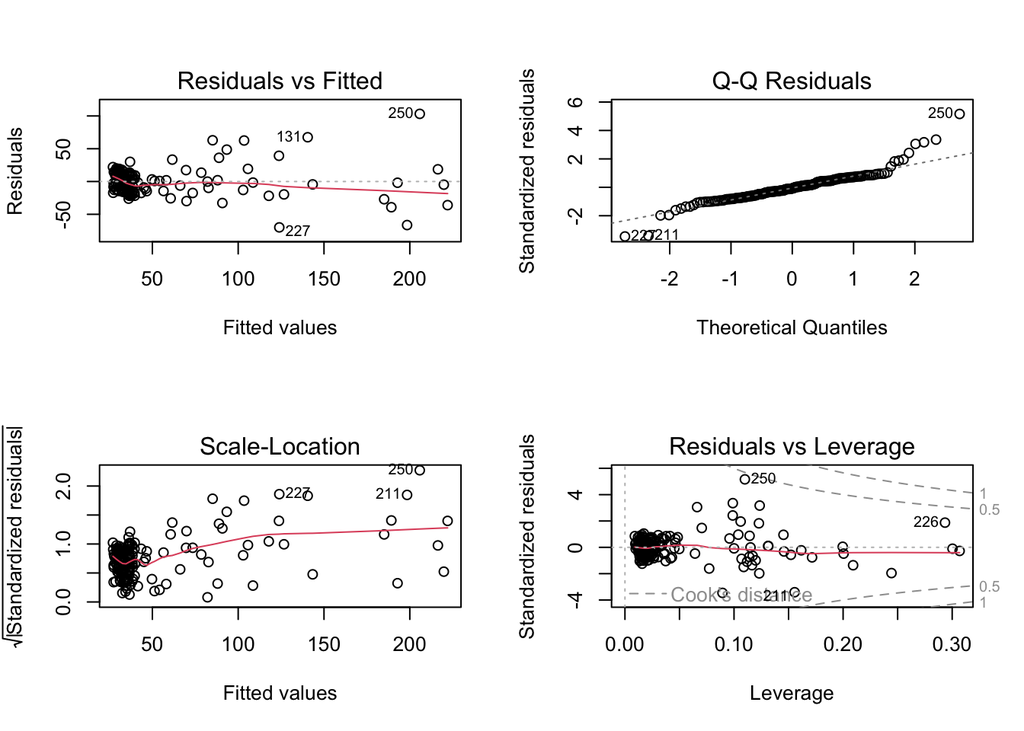

```r
par(mfrow = c(2, 2))

plot(model)
```

```r
par(mfrow = c(1, 1))
```